# ANOVAs Grwarrrr

First I’m loading the behavioraldata.csv file. And make sure all factor columns are identified as factors and all numeric columns are identified as numeric.

```r
library(tidyverse)
library(afex)
bdata <- read_csv("behavioraldata.csv") %>%
  mutate(id = factor(id),
         participant = factor(participant),
         hearing = factor(hearing),
         maingroup = factor(maingroup),
         direction = factor(direction))
bdata
```

| id | participant | hearing | maingroup | direction | age | aoasl | acc | gist |
| --- | --- | --- | --- | --- | --- | --- | --- | --- |
| 1 | Jessika | Deaf | DeafEarly | reversed | 24.00 | 3 | 0.77500 | 0.5 |
| 2 | Derek | Deaf | DeafEarly | reversed | 41.00 | 3 | 0.67500 | 0.5 |
| 3 | Vanessa | Deaf | DeafLate | forward | 34.00 | 4 | 0.82500 | 1.0 |
| 4 | Josh | Deaf | DeafLate | forward | 31.00 | 6 | 0.90000 | 1.0 |
| 5 | Lynnette | Deaf | DeafLate | reversed | 39.00 | 5 | 0.70000 | 0.5 |
| 9 | Crystal | Deaf | DeafLate | forward | 39.00 | 10 | 0.85000 | 1.0 |
| 11 | Adam | Deaf | DeafLate | reversed | 26.00 | 13 | 0.70000 | 1.0 |
| 12 | Brad | Deaf | DeafLate | reversed | 34.00 | 13 | 0.67500 | 0.0 |
| 13 | Alicia | Deaf | DeafLate | forward | 37.00 | 14 | 0.97500 | 1.0 |
| 14 | Joe | Deaf | DeafLate | forward | 44.00 | 15 | 0.90000 | 1.0 |

[output cut: 94 more lines]

# Gist

Cool. Now I’m running a 2x4 ANOVA on Gist.

- Outcome: gist
- Within subjects: direction
- Between subjects: maingroup

```r
a1 <- aov_ez("id", "gist", bdata, between = "maingroup", within = "direction")
a1
```

```
Anova Table (Type 3 tests)

Response: gist
               Effect    df  MSE         F ges p.value
1           maingroup 3, 48 0.08 11.82 *** .29  <.0001
2           direction 1, 48 0.07 78.66 *** .42  <.0001
3 maingroup:direction 3, 48 0.07   4.52 ** .11    .007
---
Signif. codes:  0 ‘***’ 0.001 ‘**’ 0.01 ‘*’ 0.05 ‘+’ 0.1 ‘ ’ 1
```

Next, I run a Forward ANOVA on Gist (between subjects: maingroup), with least-square means posthoc analyses for all pairs, with **no p-value corrections.**

```r
a2 <- aov_ez("id", "gist", filter(bdata, direction == "forward"), between = "maingroup")
a2
```

```
Anova Table (Type 3 tests)

Response: gist
     Effect    df  MSE         F ges p.value
1 maingroup 3, 48 0.05 16.11 *** .50  <.0001
---
Signif. codes:  0 ‘***’ 0.001 ‘**’ 0.01 ‘*’ 0.05 ‘+’ 0.1 ‘ ’ 1
```

```r
lsmeans(a2, "maingroup", contr = "pairwise", adjust = "none")$contrasts
```

```
 contrast                         estimate         SE df t.ratio p.value
 DeafEarly - DeafLate        -3.333333e-02 0.08413753 48  -0.396  0.6937
 DeafEarly - HearingLate     -3.333333e-02 0.08768919 48  -0.380  0.7055
 DeafEarly - HearingNovice    5.121212e-01 0.08987629 48   5.698  <.0001
 DeafLate - HearingLate      -1.110223e-16 0.08907021 48   0.000  1.0000
 DeafLate - HearingNovice     5.454545e-01 0.09122420 48   5.979  <.0001
 HearingLate - HearingNovice  5.454545e-01 0.09450992 48   5.771  <.0001
```

Next, I run a Reverse ANOVA on Gist (between subjects: maingroup), with least-square means posthoc analyses for all pairs, with **no p-value corrections.**

```r
a3 <- aov_ez("id", "gist", filter(bdata, direction == "reversed"), between = "maingroup")
a3
```

```
Anova Table (Type 3 tests)

Response: gist
     Effect    df  MSE       F ges p.value
1 maingroup 3, 48 0.10 4.77 ** .23    .005
---
Signif. codes:  0 ‘***’ 0.001 ‘**’ 0.01 ‘*’ 0.05 ‘+’ 0.1 ‘ ’ 1
```

```r
lsmeans(a3, "maingroup", contr = "pairwise", adjust = "none")$contrasts
```

```
 contrast                      estimate        SE df t.ratio p.value
 DeafEarly - DeafLate        0.27380952 0.1171597 48   2.337  0.0237
 DeafEarly - HearingLate     0.33333333 0.1221053 48   2.730  0.0088
 DeafEarly - HearingNovice   0.43939394 0.1251508 48   3.511  0.0010
 DeafLate - HearingLate      0.05952381 0.1240283 48   0.480  0.6335
 DeafLate - HearingNovice    0.16558442 0.1270277 48   1.304  0.1986
 HearingLate - HearingNovice 0.10606061 0.1316030 48   0.806  0.4243
```

# Lexical Recall

Next is a 2x4 ANOVA on Lexical Recall.

- Outcome: lexical recall
- Within subjects: direction
- Between subjects: maingroup

```r
a4 <- aov_ez("id", "acc", bdata, between = "maingroup", within = "direction")
a4
```

```
Anova Table (Type 3 tests)

Response: acc
               Effect    df  MSE          F ges p.value
1           maingroup 3, 48 0.01     4.05 * .14     .01
2           direction 1, 48 0.00 106.25 *** .43  <.0001
3 maingroup:direction 3, 48 0.00       1.96 .04     .13
---
Signif. codes:  0 ‘***’ 0.001 ‘**’ 0.01 ‘*’ 0.05 ‘+’ 0.1 ‘ ’ 1
```

Because there is no significant interaction between Subject Group and Direction, I’m going to do posthoc analyses on this anova, averaging across direction.

```r
lsmeans(a4, "maingroup", contr = "pairwise", adjust = "none")$contrasts
```

```
NOTE: Results may be misleading due to involvement in interactions
```

```
 contrast                        estimate         SE df t.ratio p.value
 DeafEarly - DeafLate         0.035439881 0.02582786 48   1.372  0.1764
 DeafEarly - HearingLate      0.030916667 0.02691812 48   1.149  0.2564
 DeafEarly - HearingNovice    0.095575758 0.02758950 48   3.464  0.0011
 DeafLate - HearingLate      -0.004523214 0.02734206 48  -0.165  0.8693
 DeafLate - HearingNovice     0.060135877 0.02800327 48   2.147  0.0368
 HearingLate - HearingNovice  0.064659091 0.02901189 48   2.229  0.0306

Results are averaged over the levels of: direction
```

Let’s do a mu test for reversed videos to make sure accuracy is significantly different than 50%.

```r
rev <- filter(bdata, direction == "reversed")
rev <- unlist(rev$acc)
t.test(rev, mu=0.5)
```

```
    One Sample t-test

data:  rev
t = 14.077, df = 51, p-value < 2.2e-16
alternative hypothesis: true mean is not equal to 0.5
95 percent confidence interval:
 0.6710372 0.7279378
sample estimates:
mean of x
0.6994875
```

# Eye Gaze

Next I load the aoidata.csv file.

```r
edata <- read_csv("aoidata.csv") %>%
  mutate(id = factor(id),
         hearing = factor(hearing),
         maingroup = factor(maingroup),
         direction = factor(direction),
         aoi = factor(aoi))
edata
```

| id | maingroup | hearing | aoasl | age | direction | aoi | percent |
| --- | --- | --- | --- | --- | --- | --- | --- |
| 1 | DeafEarly | Deaf | 3 | 24.00 | forward | eyes | 0.1817594229 |
| 1 | DeafEarly | Deaf | 3 | 24.00 | reversed | eyes | 0.3045442200 |
| 2 | DeafEarly | Deaf | 3 | 41.00 | forward | eyes | 0.0418541722 |
| 2 | DeafEarly | Deaf | 3 | 41.00 | reversed | eyes | 0.1990865083 |
| 3 | DeafLate | Deaf | 4 | 34.00 | forward | eyes | 0.0528533295 |
| 3 | DeafLate | Deaf | 4 | 34.00 | reversed | eyes | 0.0602841599 |
| 4 | DeafLate | Deaf | 6 | 31.00 | forward | eyes | 0.0016863406 |
| 4 | DeafLate | Deaf | 6 | 31.00 | reversed | eyes | 0.0008214677 |
| 5 | DeafLate | Deaf | 5 | 39.00 | forward | eyes | 0.3134020619 |
| 5 | DeafLate | Deaf | 5 | 39.00 | reversed | eyes | 0.8296795953 |

[output cut: 296 more lines]

Next we run a 3x2x4 ANOVA on eye gaze.

- Outcome: percent looking
- Within subjects: direction & AOI
- Between subjects: maingroup

```r
e1 <- aov_ez("id", "percent", edata, between = "maingroup", within = c("aoi","direction"))
e1
```

```
Anova Table (Type 3 tests)

Response: percent
                   Effect          df  MSE         F   ges p.value
1               maingroup       3, 47 0.00    3.09 *  .002     .04
2                     aoi 1.96, 91.90 0.14 38.93 ***   .41  <.0001
3           maingroup:aoi 5.87, 91.90 0.14      1.12   .06     .36
4               direction       1, 47 0.00 14.69 *** .0008   .0004
5     maingroup:direction       3, 47 0.00      0.85 .0001     .47
6           aoi:direction 1.71, 80.53 0.03   7.00 **   .02    .003
7 maingroup:aoi:direction 5.14, 80.53 0.03      0.63  .006     .68
---
Signif. codes:  0 ‘***’ 0.001 ‘**’ 0.01 ‘*’ 0.05 ‘+’ 0.1 ‘ ’ 1

Sphericity correction method: GG
```

```r
summary(e1)
```

```
HF eps > 1 treated as 1
```

```
Univariate Type III Repeated-Measures ANOVA Assuming Sphericity

                             SS num Df Error SS den Df         F    Pr(>F)
(Intercept)             29.7343      1   0.1521     47 9187.7601 < 2.2e-16 ***
maingroup                0.0300      3   0.1521     47    3.0878 0.0360291 *
aoi                     10.6704      2  12.8835     94   38.9262 4.838e-13 ***
maingroup:aoi            0.9230      6  12.8835     94    1.1224 0.3553342
direction                0.0123      1   0.0393     47   14.6917 0.0003752 ***
maingroup:direction      0.0021      3   0.0393     47    0.8510 0.4731139
aoi:direction            0.3248      2   2.1797     94    7.0029 0.0014622 **
maingroup:aoi:direction  0.0879      6   2.1797     94    0.6319 0.7044042
---
Signif. codes:  0 ‘***’ 0.001 ‘**’ 0.01 ‘*’ 0.05 ‘.’ 0.1 ‘ ’ 1


Mauchly Tests for Sphericity

                        Test statistic p-value
aoi                            0.97720 0.58833
maingroup:aoi                  0.97720 0.58833
aoi:direction                  0.83273 0.01485
maingroup:aoi:direction        0.83273 0.01485


Greenhouse-Geisser and Huynh-Feldt Corrections
 for Departure from Sphericity

                         GG eps Pr(>F[GG])
aoi                     0.97771  8.389e-13 ***
maingroup:aoi           0.97771   0.355414
aoi:direction           0.85670   0.002601 **
maingroup:aoi:direction 0.85670   0.680259
---
Signif. codes:  0 ‘***’ 0.001 ‘**’ 0.01 ‘*’ 0.05 ‘.’ 0.1 ‘ ’ 1

                           HF eps   Pr(>F[HF])
aoi                     1.0196568 4.838451e-13
maingroup:aoi           1.0196568 3.553342e-01
aoi:direction           0.8859518 2.311798e-03
maingroup:aoi:direction 0.8859518 6.854811e-01
```

```r
lsmeans(e1, "maingroup", contr = "pairwise", adjust = "none")$contrasts
```

```
 contrast                       estimate          SE df t.ratio p.value
 DeafEarly - DeafLate        0.002394751 0.008800553 47   0.272  0.7867
 DeafEarly - HearingLate     0.014815432 0.008994849 47   1.647  0.1062
 DeafEarly - HearingNovice   0.025013468 0.009219194 47   2.713  0.0093
 DeafLate - HearingLate      0.012420681 0.009297281 47   1.336  0.1880
 DeafLate - HearingNovice    0.022618717 0.009514497 47   2.377  0.0216
 HearingLate - HearingNovice 0.010198036 0.009694495 47   1.052  0.2982

Results are averaged over the levels of: aoi, direction
```

Then again for Eyes only but with only one factor: video direction.

```r
e2 <- aov_ez("id", "percent", filter(edata, aoi == "eyes"), within = "direction")
e2
```

```
Anova Table (Type 3 tests)

Response: percent
     Effect    df  MSE    F    ges p.value
1 direction 1, 50 0.02 0.00 <.0001     .96
---
Signif. codes:  0 ‘***’ 0.001 ‘**’ 0.01 ‘*’ 0.05 ‘+’ 0.1 ‘ ’ 1
```

Mouth only but with only one factor: video direction.

```r
e3 <- aov_ez("id", "percent", filter(edata, aoi == "mouth"), within = "direction")
e3
```

```
Anova Table (Type 3 tests)

Response: percent
     Effect    df  MSE        F ges p.value
1 direction 1, 50 0.02 11.14 ** .03    .002
---
Signif. codes:  0 ‘***’ 0.001 ‘**’ 0.01 ‘*’ 0.05 ‘+’ 0.1 ‘ ’ 1
```

Neck only but with only one factor: video direction.

```r
e4 <- aov_ez("id", "percent", filter(edata, aoi == "neck"), within = "direction")
e4
```

```
Anova Table (Type 3 tests)

Response: percent
     Effect    df  MSE       F ges p.value
1 direction 1, 50 0.01 9.85 ** .02    .003
---
Signif. codes:  0 ‘***’ 0.001 ‘**’ 0.01 ‘*’ 0.05 ‘+’ 0.1 ‘ ’ 1
```

# High vs. Low Performers

First I run 09finaldata and get the `fulldata` tibble to change it to `eyeperf`

```r
eyeperf <- fulldata %>%
  filter(eye_exclude == FALSE) %>%
  select(participant, maingroup, hearing, direction, aoasl, signyrs, selfrate, acc, gist, eyes, mouth, neck, facechest) %>%
  group_by(maingroup, participant, direction) %>%
  mutate(gist = mean(gist, na.rm = TRUE),
         lex = mean(acc, na.rm = TRUE),
         eyes = mean(eyes, na.rm = TRUE),
         mouth = mean(mouth, na.rm = TRUE),
         neck = mean(neck, na.rm = TRUE),
         facechest = mean(facechest, na.rm = TRUE)) %>%
  ungroup() %>%
  select(maingroup, participant, hearing, direction, aoasl, signyrs, selfrate, gist, lex, eyes, mouth, neck, facechest) %>%
  distinct() %>%
  gather(metric, value, gist:facechest) %>%
  unite(metricvalue, c(metric, direction), sep = "_") %>%
  spread(metricvalue, value) %>%
  select(-participant) %>%
  select(maingroup, hearing, aoasl, signyrs, selfrate, gist_reversed, lex_forward, lex_reversed, eyes_forward,
         eyes_reversed, mouth_forward, mouth_reversed, neck_forward, neck_reversed,
         facechest_forward, facechest_reversed)
```

[output not shown]

## Gist Reversed

| group | fcr |
| --- | --- |
| high | 0.6397941 |
| low | 0.5414191 |
| medium | 0.5052689 |
| NA | NaN |

## Lex Recall Forward (Mean)

```r
lex_fw_hl <- eyeperf %>%
  select(lex_forward, chest_forward)
lex_mean = mean(lex_fw_hl$lex_forward)
lex_fw_hl <- lex_fw_hl %>%
  mutate(group = case_when(
    lex_forward > lex_mean ~ "high",
    lex_forward <= lex_mean ~ "low")) %>%
  mutate(group = factor(group))
summary(lex_fw_hl)
```

```
  lex_forward     chest_forward       group
 Min.   :0.5750   Min.   :0.000000   high:29
 1st Qu.:0.8187   1st Qu.:0.001618   low :23
 Median :0.8500   Median :0.004737
 Mean   :0.8425   Mean   :0.022955
 3rd Qu.:0.9000   3rd Qu.:0.009964
 Max.   :1.0000   Max.   :0.286304
```

```r
lex_fw_high = filter(lex_fw_hl, group == "high") %>% select(chest_forward)
lex_fw_low = filter(lex_fw_hl, group == "low") %>% select(chest_forward)
lexfw_high = unlist(lex_fw_high$chest_forward)
lexfw_low = unlist(lex_fw_low$chest_forward)
t.test(lexfw_high, lexfw_low)
```

```
    Welch Two Sample t-test

data:  lexfw_high and lexfw_low
t = -1.0725, df = 31.612, p-value = 0.2916
alternative hypothesis: true difference in means is not equal to 0
95 percent confidence interval:
 -0.04749186  0.01474004
sample estimates:
 mean of x  mean of y
0.01571203 0.03208794
```

## Lex Recall Forward (Median)

```r
lex_fw_hl <- eyeperf %>%
  select(lex_forward, chest_forward)
lex_med = median(lex_fw_hl$lex_forward)
lex_fw_hl <- lex_fw_hl %>%
  mutate(group = case_when(
    lex_forward > lex_med ~ "high",
    lex_forward <= lex_med ~ "low")) %>%
  mutate(group = factor(group))
summary(lex_fw_hl)
```

```
  lex_forward     chest_forward       group
 Min.   :0.5750   Min.   :0.000000   high:24
 1st Qu.:0.8187   1st Qu.:0.001618   low :28
 Median :0.8500   Median :0.004737
 Mean   :0.8425   Mean   :0.022955
 3rd Qu.:0.9000   3rd Qu.:0.009964
 Max.   :1.0000   Max.   :0.286304
```

```r
lex_fw_high = filter(lex_fw_hl, group == "high") %>% select(chest_forward)
lex_fw_low = filter(lex_fw_hl, group == "low") %>% select(chest_forward)
lexfw_high = unlist(lex_fw_high$chest_forward)
lexfw_low = unlist(lex_fw_low$chest_forward)
t.test(lexfw_high, lexfw_low)
```

```
    Welch Two Sample t-test

data:  lexfw_high and lexfw_low
t = -2.1156, df = 29.774, p-value = 0.04286
alternative hypothesis: true difference in means is not equal to 0
95 percent confidence interval:
 -0.0537617278 -0.0009392749
sample estimates:
  mean of x   mean of y
0.008228028 0.035578529
```

## Lex Recall Reverse (Mean)

```r
lex_fw_hl <- eyeperf %>%
  select(lex_reversed, chest_reversed)
lex_mean = mean(lex_fw_hl$lex_reversed, na.rm = TRUE)
lex_fw_hl <- lex_fw_hl %>%
  mutate(group = case_when(
    lex_reversed > lex_mean ~ "high",
    lex_reversed <= lex_mean ~ "low")) %>%
  mutate(group = factor(group))
summary(lex_fw_hl)
```

```
  lex_reversed    chest_reversed      group
 Min.   :0.4500   Min.   :0.000000   high:27
 1st Qu.:0.6250   1st Qu.:0.002867   low :24
 Median :0.7000   Median :0.009494   NA's: 1
 Mean   :0.6882   Mean   :0.044046
 3rd Qu.:0.7750   3rd Qu.:0.053294
 Max.   :0.9500   Max.   :0.315759
 NA's   :1        NA's   :1
```

```r
lex_fw_high = filter(lex_fw_hl, group == "high") %>% select(chest_reversed)
lex_fw_low = filter(lex_fw_hl, group == "low") %>% select(chest_reversed)
lexfw_high = unlist(lex_fw_high$chest_reversed)
lexfw_low = unlist(lex_fw_low$chest_reversed)
t.test(lexfw_high, lexfw_low)
```

```
    Welch Two Sample t-test

data:  lexfw_high and lexfw_low
t = -1.0014, df = 39.773, p-value = 0.3227
alternative hypothesis: true difference in means is not equal to 0
95 percent confidence interval:
 -0.06263109  0.02113581
sample estimates:
 mean of x  mean of y
0.03428186 0.05502950
```

## Lex Recall Reverse (Median)

p = 0.60 or more, doesn’t matter where the median is in.

```r
lex_fw_hl <- eyeperf %>%
  select(lex_reversed, chest_reversed)
lex_mean = median(lex_fw_hl$lex_reversed, na.rm = TRUE)
lex_fw_hl <- lex_fw_hl %>%
  mutate(group = case_when(
    lex_reversed > lex_mean ~ "high",
    lex_reversed <= lex_mean ~ "low")) %>%
  mutate(group = factor(group))
summary(lex_fw_hl)
```

```
  lex_reversed    chest_reversed      group
 Min.   :0.4500   Min.   :0.000000   high:21
 1st Qu.:0.6250   1st Qu.:0.002867   low :30
 Median :0.7000   Median :0.009494   NA's: 1
 Mean   :0.6882   Mean   :0.044046
 3rd Qu.:0.7750   3rd Qu.:0.053294
 Max.   :0.9500   Max.   :0.315759
 NA's   :1        NA's   :1
```

```r
lex_fw_high = filter(lex_fw_hl, group == "high") %>% select(chest_reversed)
lex_fw_low = filter(lex_fw_hl, group == "low") %>% select(chest_reversed)
lexfw_high = unlist(lex_fw_high$chest_reversed)
lexfw_low = unlist(lex_fw_low$chest_reversed)
t.test(lexfw_high, lexfw_low)
```

```
    Welch Two Sample t-test

data:  lexfw_high and lexfw_low
t = -0.35981, df = 47.602, p-value = 0.7206
alternative hypothesis: true difference in means is not equal to 0
95 percent confidence interval:
 -0.04752035  0.03309670
sample estimates:
 mean of x  mean of y
0.03980321 0.04701503
```

# Top v Bottom 25% Performers

Let’s try this again but with top and bottom 25% people.

“It makes total sense to me why that [high v. low] approach doesn’t work, because many who are right around the median don’t help address what happens when you have GOOD comprehension (i.e. ABOVE average) vs POOR, especially if you have a lot who straddle the median. SO you need to move toward the ends.”

## Gist Reversed

Well, that’s not going to work becuase we just have three possible scores - 0, 0.5, and 1. I’ll try that as three groups! And do an ANOVA.

```r
gist_hl <- eyeperf %>%
  select(gist_reversed, chest_reversed) %>%
  mutate(group = case_when(
    gist_reversed == 0 ~ "low",
    gist_reversed == 0.5 ~ "middle",
    gist_reversed == 1 ~ "high"
  )) %>%
  mutate(group = factor(group)) %>%
  select(-gist_reversed)
id = seq(1,nrow(gist_hl))
gist_hl = cbind(gist_hl, id)


g1 <- aov_ez("id", "chest_reversed", gist_hl, between = "group")
```

```
Missing values for following ID(s):
24
Removing those cases from the analysis.Contrasts set to contr.sum for the following variables: group
```

```r
g1
```

```
Anova Table (Type 3 tests)

Response: chest_reversed
  Effect    df  MSE    F ges p.value
1  group 2, 48 0.01 1.28 .05     .29
---
Signif. codes:  0 ‘***’ 0.001 ‘**’ 0.01 ‘*’ 0.05 ‘+’ 0.1 ‘ ’ 1
```

## Lex Recall Forward

```r
lex_fw_hl <- eyeperf %>%
  select(lex_forward, chest_forward)
lex_quartiles = quantile(lex_fw_hl$lex_forward, probs = c(0.25, 0.75))
lex_fw_hl <- lex_fw_hl %>%
  mutate(group = case_when(
    lex_forward >= lex_quartiles[2] ~ "high",
    lex_forward <= lex_quartiles[1] ~ "low")) %>%
  mutate(group = factor(group)) %>%
  filter(!is.na(group))
summary(lex_fw_hl)
```

```
  lex_forward     chest_forward       group
 Min.   :0.5750   Min.   :0.000000   high:15
 1st Qu.:0.7712   1st Qu.:0.001493   low :13
 Median :0.9000   Median :0.004337
 Mean   :0.8346   Mean   :0.011610
 3rd Qu.:0.9012   3rd Qu.:0.009964
 Max.   :1.0000   Max.   :0.081668
```

```r
lex_fw_high = filter(lex_fw_hl, group == "high") %>% select(chest_forward)
lex_fw_low = filter(lex_fw_hl, group == "low") %>% select(chest_forward)
lexfw_high = unlist(lex_fw_high$chest_forward)
lexfw_low = unlist(lex_fw_low$chest_forward)
t.test(lexfw_high, lexfw_low)
```

```
    Welch Two Sample t-test

data:  lexfw_high and lexfw_low
t = -0.16511, df = 22.425, p-value = 0.8703
alternative hypothesis: true difference in means is not equal to 0
95 percent confidence interval:
 -0.01712561  0.01459725
sample estimates:
 mean of x  mean of y
0.01102292 0.01228710
```

## Lex Recall Reverse

```r
lex_fw_hl <- eyeperf %>%
  select(lex_reversed, chest_reversed) %>%
  filter(!is.na(lex_reversed))
lex_quartiles = quantile(lex_fw_hl$lex_reversed, probs = c(0.25, 0.75))
lex_fw_hl <- lex_fw_hl %>%
  mutate(group = case_when(
    lex_reversed >= lex_quartiles[2] ~ "high",
    lex_reversed <= lex_quartiles[1] ~ "low")) %>%
  mutate(group = factor(group)) %>%
  filter(!is.na(group))
summary(lex_fw_hl)
```

```
  lex_reversed    chest_reversed      group
 Min.   :0.4500   Min.   :0.000000   high:15
 1st Qu.:0.5750   1st Qu.:0.003583   low :14
 Median :0.7750   Median :0.012058
 Mean   :0.6845   Mean   :0.048192
 3rd Qu.:0.8000   3rd Qu.:0.069088
 Max.   :0.9500   Max.   :0.252839
```

```r
lex_fw_high = filter(lex_fw_hl, group == "high") %>% select(chest_reversed)
lex_fw_low = filter(lex_fw_hl, group == "low") %>% select(chest_reversed)
lexfw_high = unlist(lex_fw_high$chest_reversed)
lexfw_low = unlist(lex_fw_low$chest_reversed)
t.test(lexfw_high, lexfw_low)
```

```
    Welch Two Sample t-test

data:  lexfw_high and lexfw_low
t = -0.26189, df = 26.485, p-value = 0.7954
alternative hypothesis: true difference in means is not equal to 0
95 percent confidence interval:
 -0.06444359  0.04986646
sample estimates:
 mean of x  mean of y
0.04467305 0.05196161
```

## Scatterplots

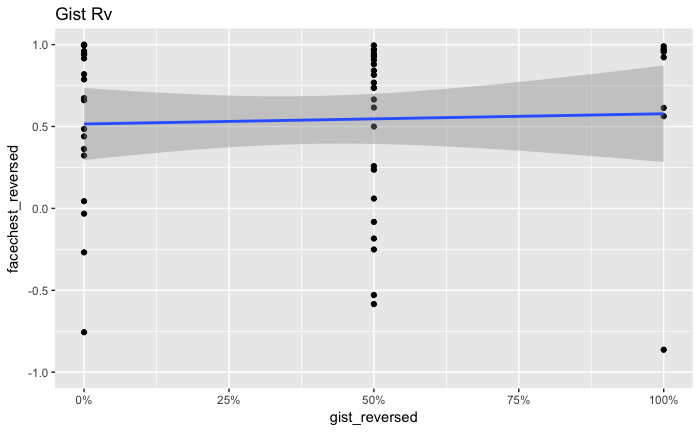

```r
library(scales)
ggplot(eyeperf, aes(x = gist_reversed, y = facechest_reversed)) +
  geom_point() + geom_smooth(method = "lm") +
  scale_x_continuous(labels = percent) +
  scale_y_continuous(limits = c(-1,1)) + ggtitle("Gist Rv")
```

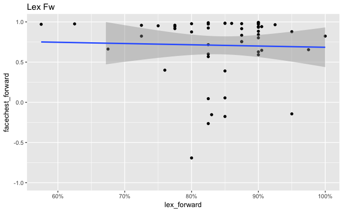

```r
ggplot(eyeperf, aes(x = lex_forward, y = facechest_forward)) +
  geom_point() + geom_smooth(method = "lm") +
  scale_x_continuous(labels = percent) +
  scale_y_continuous(limits = c(-1,1)) + ggtitle("Lex Fw")
```

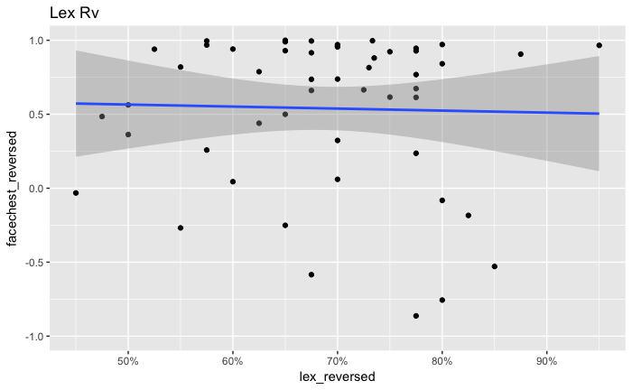

```r
ggplot(eyeperf, aes(x = lex_reversed, y = facechest_reversed)) +
  geom_point() + geom_smooth(method = "lm") +
  scale_x_continuous(labels = percent) +
  scale_y_continuous(limits = c(-1,1)) + ggtitle("Lex Rv")
```

# Repeated Measures Correlations

OKAY! I found [this article](https://www.frontiersin.org/articles/10.3389/fpsyg.2017.00456/full#h11) which discusses correlations with repeated measures, and it involves the `rmcorr` package. Let’s give that a spin.

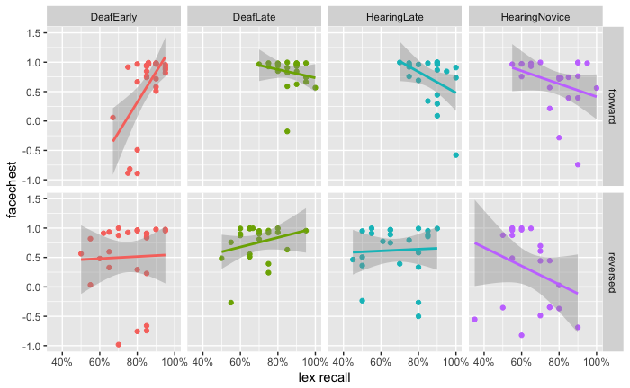

# Regular Correlation by Groups

## Deaf Early

|  | lex |
| --- | --- |
| lex |  |
| facechest | 0.17 |

```r
eyeperf %>% filter(maingroup == "DeafLate") %>% select(lex_forward,
                                                       lex_reversed,
                                                       facechest_forward,
                                                       facechest_reversed) %>%
  corstarsl(.)
```

|  | lex_forward | lex_reversed | facechest_forward |
| --- | --- | --- | --- |
| lex_forward |  |  |  |
| lex_reversed | 0.28 |  |  |
| facechest_forward | -0.16 | 0.63* |  |
| facechest_reversed | 0.08 | 0.70** | 0.89*** |

```r
eyeperf1 <- eyeperf %>% filter(maingroup == "DeafLate") %>%
  select(lex_forward, facechest_forward) %>%
  rename(lex = lex_forward,
         facechest = facechest_forward)
eyeperf2 <- eyeperf %>% filter(maingroup == "DeafLate") %>%
  select(lex_reversed, facechest_reversed) %>%
  rename(lex = lex_reversed,
         facechest = facechest_reversed)
rbind(eyeperf1, eyeperf2) %>% corstarsl(.)
```

|  | lex |
| --- | --- |
| lex |  |
| facechest | 0.25 |

```r
eyeperf %>% filter(maingroup == "HearingLate") %>% select(lex_forward,
                                                       lex_reversed,
                                                       facechest_forward,
                                                       facechest_reversed) %>%
  corstarsl(.)
```

|  | lex_forward | lex_reversed | facechest_forward |
| --- | --- | --- | --- |
| lex_forward |  |  |  |
| lex_reversed | -0.04 |  |  |
| facechest_forward | -0.42 | -0.13 |  |
| facechest_reversed | -0.37 | 0.06 | 0.81** |

```r
eyeperf1 <- eyeperf %>% filter(maingroup == "HearingLate") %>%
  select(lex_forward, facechest_forward) %>%
  rename(lex = lex_forward,
         facechest = facechest_forward)
eyeperf2 <- eyeperf %>% filter(maingroup == "HearingLate") %>%
  select(lex_reversed, facechest_reversed) %>%
  rename(lex = lex_reversed,
         facechest = facechest_reversed)
rbind(eyeperf1, eyeperf2) %>% corstarsl(.)
```

|  | lex |
| --- | --- |
| lex |  |
| facechest | 0.04 |

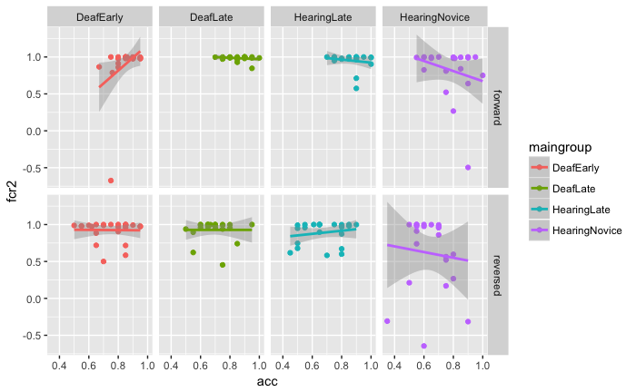

# Partial Correlations

First, run 09finaldata all the way (but for this, especially to line ~560 - Eye Gaze Data)

```r
library(ppcor)
lexgist_deaf %>%
  dplyr::select(aoasl, signyrs, gist_reversed) %>%
  as.matrix() %>%
  pcor()
```

```
$estimate
                   aoasl    signyrs gist_reversed
aoasl          1.0000000 -0.5225511    -0.3031725
signyrs       -0.5225511  1.0000000    -0.1686937
gist_reversed -0.3031725 -0.1686937     1.0000000

$p.value
                   aoasl    signyrs gist_reversed
aoasl         0.00000000 0.00433467     0.1168189
signyrs       0.00433467 0.00000000     0.3908262
gist_reversed 0.11681893 0.39082619     0.0000000

$statistic
                  aoasl    signyrs gist_reversed
aoasl          0.000000 -3.1251150    -1.6222318
signyrs       -3.125115  0.0000000    -0.8726795
gist_reversed -1.622232 -0.8726795     0.0000000

$n
[1] 29

$gp
[1] 1

$method
[1] "pearson"
```

```r
lexgist_deaf %>%
  dplyr::select(aoasl, signyrs, lex_reversed) %>%
  as.matrix() %>%
  pcor()
```

```
$estimate
                  aoasl     signyrs lex_reversed
aoasl         1.0000000 -0.50264736  -0.25788564
signyrs      -0.5026474  1.00000000  -0.07393946
lex_reversed -0.2578856 -0.07393946   1.00000000

$p.value
                   aoasl     signyrs lex_reversed
aoasl        0.000000000 0.006410064    0.1851948
signyrs      0.006410064 0.000000000    0.7084598
lex_reversed 0.185194817 0.708459848    0.0000000

$statistic
                 aoasl    signyrs lex_reversed
aoasl         0.000000 -2.9647586   -1.3609991
signyrs      -2.964759  0.0000000   -0.3780536
lex_reversed -1.360999 -0.3780536    0.0000000

$n
[1] 29

$gp
[1] 1

$method
[1] "pearson"
```